# human Resources

2017-07-13

# Intro

Hello there! In this notebook I will look at popular HR dataset and will try to solve some problems and draw some graphs.

# Prerequisites

Libraries

```r
library(ggplot2)
library(gridExtra)
library(dplyr)
library(magrittr)
library(reshape2)
library(corrplot)
library(broom)
library(scales)
library(rpart.plot)
library(rpart)
library(knitr)
library(kableExtra)
```

Now load data:

```r
hr_data <- read.csv('../data/HR_comma_sep.csv')
```

# EDA

## Data types, missed values

```r
glimpse(hr_data)
```

```
## Observations: 14,999
## Variables: 10
## $ satisfaction_level    <dbl> 0.38, 0.80, 0.11, 0.72, 0.37, 0.41, 0.10...
## $ last_evaluation       <dbl> 0.53, 0.86, 0.88, 0.87, 0.52, 0.50, 0.77...
## $ number_project        <int> 2, 5, 7, 5, 2, 2, 6, 5, 5, 2, 2, 6, 4, 2...
## $ average_montly_hours  <int> 157, 262, 272, 223, 159, 153, 247, 259, ...
## $ time_spend_company    <int> 3, 6, 4, 5, 3, 3, 4, 5, 5, 3, 3, 4, 5, 3...
## $ Work_accident         <int> 0, 0, 0, 0, 0, 0, 0, 0, 0, 0, 0, 0, 0, 0...
## $ left                  <int> 1, 1, 1, 1, 1, 1, 1, 1, 1, 1, 1, 1, 1, 1...
## $ promotion_last_5years <int> 0, 0, 0, 0, 0, 0, 0, 0, 0, 0, 0, 0, 0, 0...
## $ sales                 <fctr> sales, sales, sales, sales, sales, sale...
## $ salary                <fctr> low, medium, medium, low, low, low, low...
```

Hm… ‘sales’ column is looking to be a department, rename. Also, will format names a bit, and then will look at missed values.

```r
hr_data %<>% rename(department = sales,
                    work_accident = Work_accident,
                    average_monthly_hours = average_montly_hours,
                    time_spent_company = time_spend_company)
```

```r
hr_data %>%
  sapply(function(x) sum(is.na(x))) %>%
  tidy %>%
  kable(format = 'html', col.names = c('Variable', '№ of NA')) %>%
  kable_styling(bootstrap_options = c('condensed', 'striped'), full_width = FALSE)
```

| Variable | № of NA |
| --- | --- |
| satisfaction_level | 0 |
| last_evaluation | 0 |
| number_project | 0 |
| average_monthly_hours | 0 |
| time_spent_company | 0 |
| work_accident | 0 |
| left | 0 |
| promotion_last_5years | 0 |
| department | 0 |
| salary | 0 |

Good, no missed values. Little retyping, since ‘left’, ‘work_accident’ and ‘promotion_last_5years’ are factors.

```r
hr_data %<>% mutate(promotion_last_5years = factor(promotion_last_5years, levels = c(1, 0), labels = c('Yes', 'No')),
                    left = factor(left, levels = c(1, 0), labels = c('Yes', 'No')),
                    work_accident = factor(work_accident, levels = c(1, 0), labels = c('Yes', 'No')))
```

## Density plots

First of all, summary:

```r
summary(hr_data)
```

```
##  satisfaction_level last_evaluation  number_project  average_monthly_hours
##  Min.   :0.0900     Min.   :0.3600   Min.   :2.000   Min.   : 96.0
##  1st Qu.:0.4400     1st Qu.:0.5600   1st Qu.:3.000   1st Qu.:156.0
##  Median :0.6400     Median :0.7200   Median :4.000   Median :200.0
##  Mean   :0.6128     Mean   :0.7161   Mean   :3.803   Mean   :201.1
##  3rd Qu.:0.8200     3rd Qu.:0.8700   3rd Qu.:5.000   3rd Qu.:245.0
##  Max.   :1.0000     Max.   :1.0000   Max.   :7.000   Max.   :310.0
##
##  time_spent_company work_accident  left       promotion_last_5years
##  Min.   : 2.000     Yes: 2169     Yes: 3571   Yes:  319
##  1st Qu.: 3.000     No :12830     No :11428   No :14680
##  Median : 3.000
##  Mean   : 3.498
##  3rd Qu.: 4.000
##  Max.   :10.000
##
##        department      salary
##  sales      :4140   high  :1237
##  technical  :2720   low   :7316
##  support    :2229   medium:6446
##  IT         :1227
##  product_mng: 902
##  marketing  : 858
##  (Other)    :2923
```

Now, lets look at density plots for continuous values and discrete plots for discrete ones.

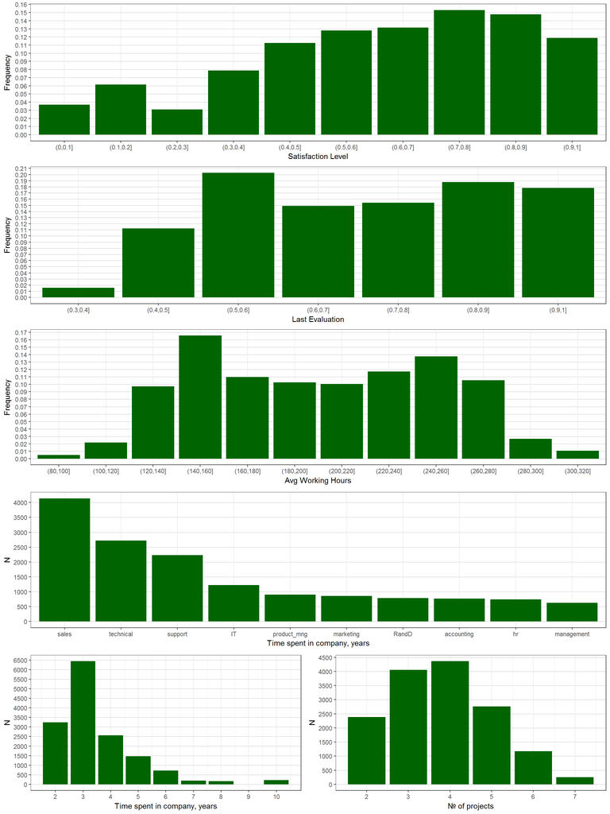

```r
sat_level <- hr_data %>%
  mutate(bin = cut(satisfaction_level, breaks = seq(0, 1, by = .1))) %>%
  group_by(bin) %>%
  count() %>%
  ungroup() %>%
  mutate(freq = n / sum(n)) %>%
  ggplot() +
    geom_bar(aes(x = bin, y = freq), stat = 'identity', fill = 'darkgreen') +
    scale_y_continuous(breaks = seq(0, 1, by = .01)) +
    labs(x = 'Satisfaction Level', y = 'Frequency') +
    theme_bw() +
    theme(panel.grid.major.y = element_line(color = 'grey', size = .1),
          panel.grid.minor.y = element_blank())

last_eval <- hr_data %>%
  mutate(bin = cut(last_evaluation, breaks = seq(0, 1, by = .1))) %>%
  group_by(bin) %>%
  count() %>%
  ungroup() %>%
  mutate(freq = n / sum(n)) %>%
  ggplot() +
    geom_bar(aes(x = bin, y = freq), stat = 'identity', fill = 'darkgreen') +
    scale_y_continuous(breaks = seq(0, 1, by = .01)) +
    labs(x = 'Last Evaluation', y = 'Frequency') +
    theme_bw() +
    theme(panel.grid.major.y = element_line(color = 'grey', size = .1),
          panel.grid.minor.y = element_blank())

avg_hours <- hr_data %>%
  mutate(bin = cut(average_monthly_hours, breaks = seq(0, 400, by = 20))) %>%
  group_by(bin) %>%
  count() %>%
  ungroup() %>%
  mutate(freq = n / sum(n)) %>%
  ggplot() +
    geom_bar(aes(x = bin, y = freq), stat = 'identity', fill = 'darkgreen') +
    scale_y_continuous(breaks = seq(0, 1, by = .01)) +
    labs(x = 'Avg Working Hours', y = 'Frequency') +
    theme_bw() +
    theme(panel.grid.major.y = element_line(color = 'grey', size = .1),
          panel.grid.minor.y = element_blank())
department <- hr_data %>%
  group_by(department) %>%
  count() %>%
  ggplot() +
    geom_bar(aes(x = reorder(department, -n), y = n), stat = 'identity', fill = 'darkgreen') +
    labs(x = 'Time spent in company, years', y = 'N') +
    scale_y_continuous(breaks = seq(0, 7000, by = 500)) +
    theme_bw() +
    theme(panel.grid.major.y = element_line(color = 'grey', size = .1),
          panel.grid.minor.y = element_blank())

time_spent <- hr_data %>%
  ggplot() +
    geom_bar(aes(x = time_spent_company), stat = 'count', fill = 'darkgreen') +
    scale_x_continuous(breaks = seq(min(hr_data$time_spent_company), max(hr_data$time_spent_company), by = 1)) +
    labs(x = 'Time spent in company, years', y = 'N') +
    scale_y_continuous(breaks = seq(0, 7000, by = 500)) +
    theme_bw() +
    theme(panel.grid.major.y = element_line(color = 'grey', size = .1),
          panel.grid.minor.y = element_blank())

projects <- hr_data %>%
  ggplot() +
    geom_bar(aes(x = number_project), stat = 'count', fill = 'darkgreen') +
    scale_x_continuous(breaks = seq(min(hr_data$number_project), max(hr_data$number_project), by = 1)) +
    labs(x = '№ of projects', y = 'N') +
    scale_y_continuous(breaks = seq(0, 5000, by = 500)) +
    theme_bw() +
    theme(panel.grid.major.y = element_line(color = 'grey', size = .1),
          panel.grid.minor.y = element_blank())

layout <- rbind(c(1, 1),
                c(2, 2),
             c(3, 3),
             c(4, 4),
             c(5, 6))
grid.arrange(grobs = list(sat_level, last_eval, avg_hours, department, time_spent, projects), layout_matrix = layout)
```

Cool! Now, our factor variables.

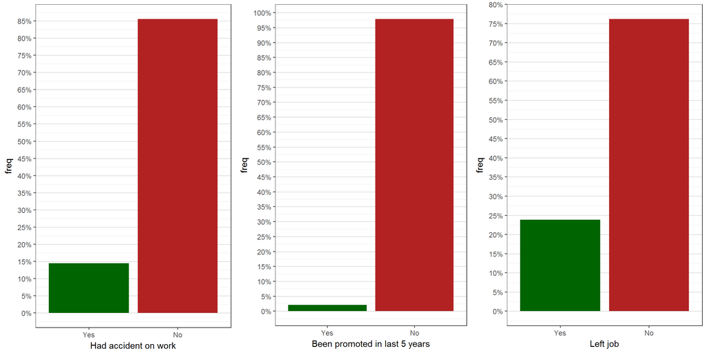

```r
accident <- hr_data %>% count(work_accident) %>% mutate(freq = n / sum(n)) %>%
  ggplot() +
  geom_bar(aes(x = work_accident, fill = work_accident, y = freq), stat = 'identity') +
  scale_fill_manual(values = c('darkgreen', 'firebrick'), guide = FALSE) +
  scale_y_continuous(breaks = seq(0, 1, by = .05), labels = percent) +
  xlab('Had accident on work') +
  theme_bw() +
  theme(panel.grid.major.y = element_line(size = .1, color = 'grey'),
        panel.grid.major.x = element_blank())

promo <- hr_data %>% count(promotion_last_5years) %>% mutate(freq = n / sum(n)) %>%
  ggplot() +
  geom_bar(aes(x = promotion_last_5years, fill = promotion_last_5years, y = freq), stat = 'identity') +
  scale_fill_manual(values = c('darkgreen', 'firebrick'), guide = FALSE) +
  scale_y_continuous(breaks = seq(0, 1, by = .05), labels = percent) +
  xlab('Been promoted in last 5 years') +
  theme_bw() +
  theme(panel.grid.major.y = element_line(size = .1, color = 'grey'),
        panel.grid.major.x = element_blank())

left <- hr_data %>% count(left) %>% mutate(freq = n / sum(n)) %>%
  ggplot() +
  geom_bar(aes(x = left, fill = left, y = freq), stat = 'identity') +
  scale_fill_manual(values = c('darkgreen', 'firebrick'), guide = FALSE) +
  scale_y_continuous(breaks = seq(0, 1, by = .05), labels = percent) +
  xlab('Left job') +
  theme_bw() +
  theme(panel.grid.major.y = element_line(size = .1, color = 'grey'),
        panel.grid.major.x = element_blank())

layout <- rbind(c(1, 2, 3))
grid.arrange(grobs = list(accident, promo, left), layout_matrix = layout)
```

So, very few been promoted, about quarter of people left their job.

Ok, let’s look at correlogram.

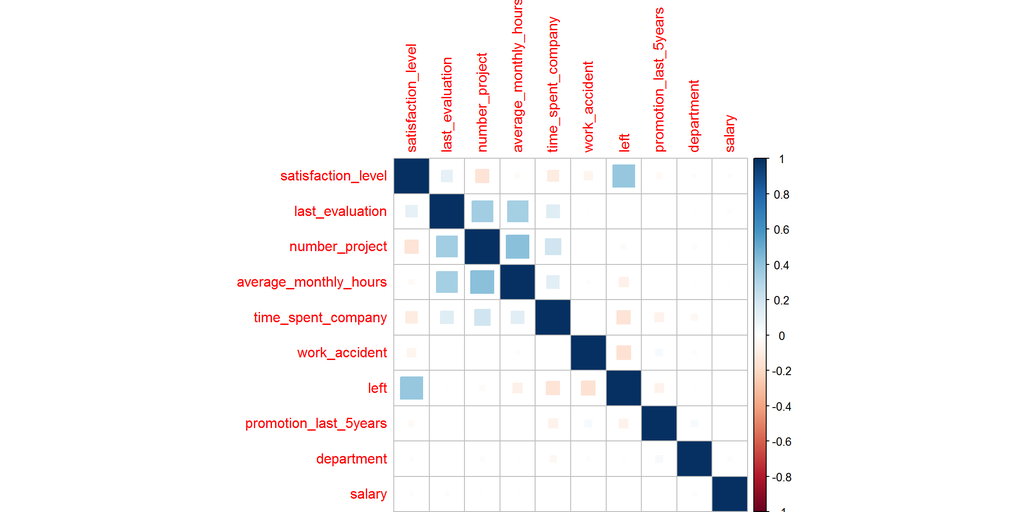

```r
hr_data %>% mutate(work_accident = as.numeric(work_accident),
                   left = as.numeric(left),
                   promotion_last_5years = as.numeric(promotion_last_5years),
                   department = as.numeric(department),
                   salary = as.numeric(salary)) %>% cor %>% corrplot(method = c('square'))
```

# Some sort of practical analysis

So, why people leave? Let’s figure out. In lazy way, we’ll make decision tree model, look at it’s internals, and then will build graphs. :)

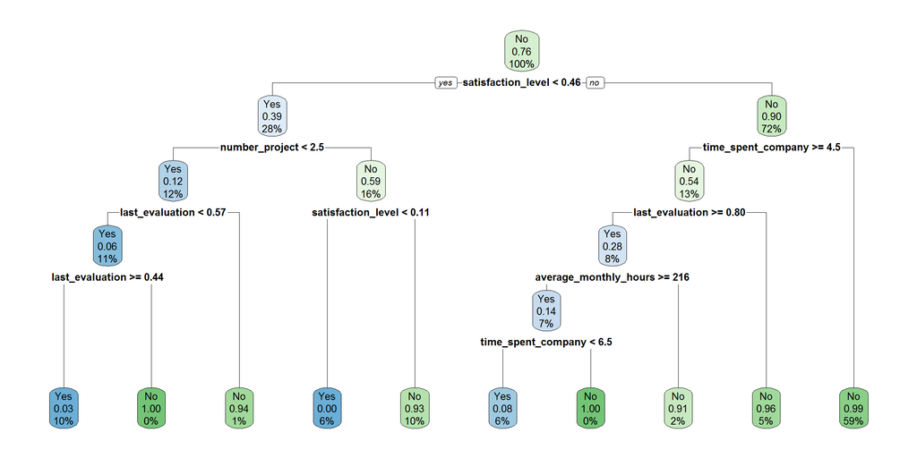

```r
model <- rpart(left~., hr_data)
rpart.plot(model)
```

So, main concern is satisfaction level. Let’s see difference of distribution between left and stayed employees.

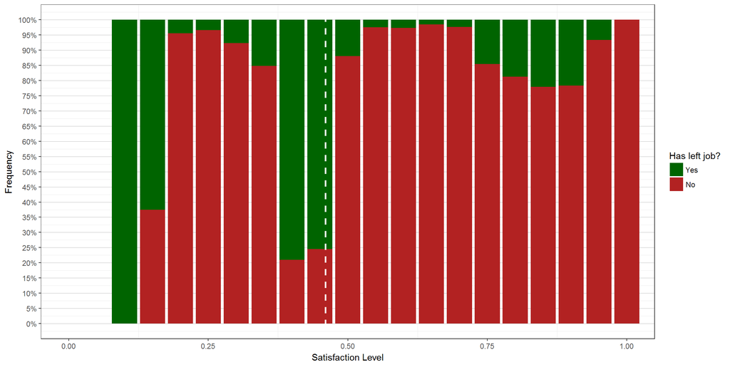

```r
hr_data %>%
  select(left, satisfaction_level) %>%
  mutate(bin = cut(satisfaction_level, breaks = seq(0, 1, by = .05), labels = FALSE) / 20) %>%
  group_by(bin, left) %>%
  count() %>%
  ungroup() %>%
  group_by(bin) %>%
  mutate(freq = n / sum(n)) %>%
  ggplot() +
    geom_bar(aes(x = bin, y = freq, fill = left), stat = 'identity') +
    scale_fill_manual(values = c('darkgreen', 'firebrick')) +
    geom_vline(aes(xintercept = .46), color = 'white', linetype = 'dashed', size = 1) +
    scale_color_manual(values = c('darkgreen', 'orangered')) +
    guides(fill = guide_legend(title = 'Has left job?')) +
    coord_cartesian(xlim = c(0, 1), ylim = c(0, 1)) +
    labs(x = 'Satisfaction Level', y = 'Frequency') +
    theme_bw() +
    scale_y_continuous(breaks = seq(0, 1, by = .05), labels = percent) +
    theme(panel.grid.major.y = element_line(size = .1, color = 'grey'),
          panel.grid.major.x = element_blank())
```

Dashed line is the boundary decision from a tree. Looks like we can locate 2 big groups with this decision boundary. One still left, so we go down right on the tree and check next 2 variables.

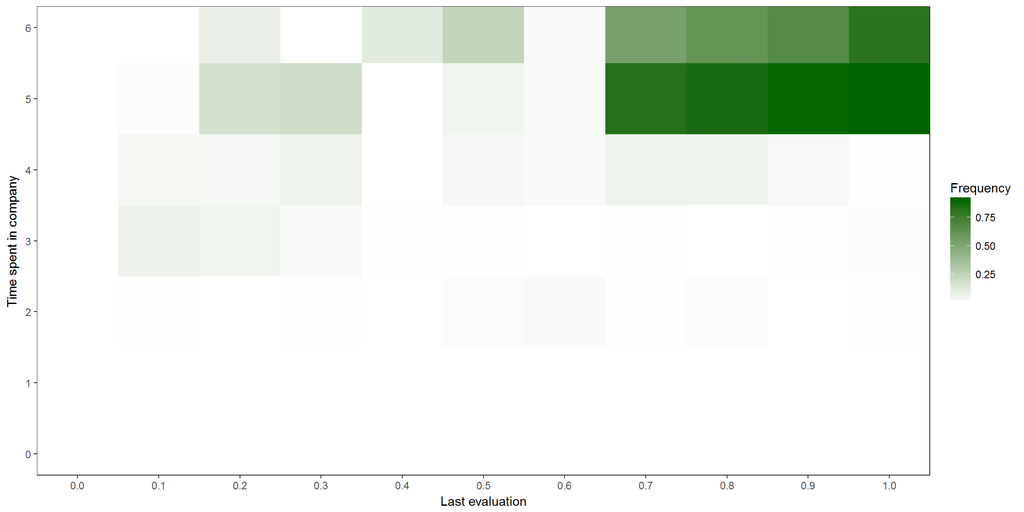

```r
hr_data %>%
  filter(satisfaction_level >= .46) %>%
  mutate(bin = ntile(last_evaluation, 10)/10) %>%
  group_by(bin, time_spent_company) %>%
  count(left) %>%
  mutate(freq = n / sum(n)) %>%
  filter(left == 'Yes') %>%
  ggplot(aes(bin, time_spent_company)) +
    geom_tile(aes(fill = freq)) +
    coord_cartesian(xlim = c(0, 1), ylim = c(0, 6)) +
    scale_y_continuous(breaks = seq(0, 6, by = 1)) +
    scale_x_continuous(breaks = seq(0, 1, by = .1)) +
    labs(x = 'Last evaluation', y = 'Time spent in company', fill = 'Frequency') +
    scale_fill_gradient(low = 'white', high = 'darkgreen') +
    theme_bw() +
    theme(panel.grid = element_blank())
```

Ok, another zone is localized, big possibility to leave is for men who worked for 5+ years and was highly productive by their last measures. Judging by decision tree, we can guess that you probably leave from your job if:

-You’re non-satisfied with your job and also not on high load. -You’re on high load and really pissed off. -You just retire.

Well, that’s it for now. :)